# AR-MA manual

Ravi Mahesa Pramudya (G1401211052)

2023-09-21

## White Noise

Pembangkitan data berpola AR, MA, ARMA, dan banyak proses deret waktu lainnya diawali pembangkitan *white noise*. *White noise* merupakan sederet nilai dari peubah bebas stokastik identik. Oleh karena itu, *white noise* memiliki dua karakteristik penting:

1. *White noise* tidak memiliki autokorelasi (**karena saling bebas**)
2. Nilai harapan dan ragam *white noise* sama (**karena berasal dari peubah acak bebas stokastik identik**)

*White noise* dibangkitkan dari suatu peubah acak, umumnya peubah acak normal.

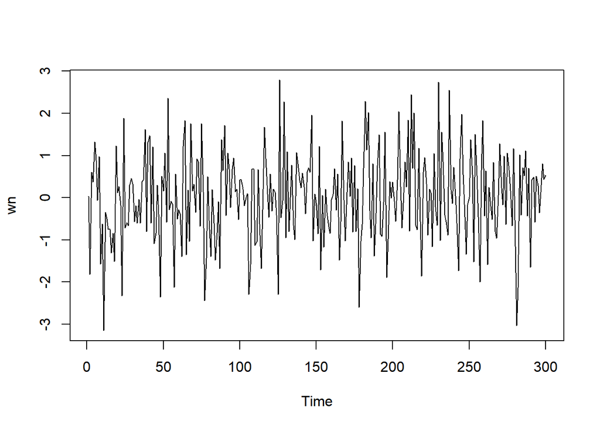

```r
wn <- rnorm(300)
ts.plot(wn)
```

Dapat terlihat bahwa *white noise* tidak memiliki autokorelasi dari ACF. Perhatikan bahwa lag ke-0 adalah korelasi observasi ke-t dengan dirinya sendiri. Nilai korelasi tersebut pasti 1. Sebagai alternatif, lag pertama di plot ACF dapat ditetapkan sebagai 1 (alih-alih 0) dengan menambahkan argumen `xlim(1, lag akhir)`. Plot tersebut dapat disandingkan bersamaan dengan membuat matriks $1 \times 2$ dengan `par(mfrow = c(1,2))`.

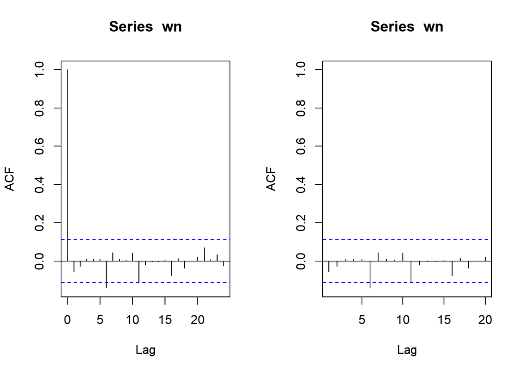

```r
par(mfrow = c(1, 2))
acf(wn)
acf(wn, xlim = c(1, 20))
```

## Proses MA

Proses MA dapat dituliskan sebagai berikut:

$$y_{t} = c + e_t + \theta_{1}e_{t-1} + \theta_{2}e_{t-2} + \dots +
\theta_{q}e_{t-q} = c+{e_t+\sum_{i=1}^p \theta_ie_{t-i}}$$
Terlihat bahwa $e_t$, atau *white noise*, berperan penting dalam pembangkitan proses MA.

## Pembangkitan Proses MA(2)

Akan dicoba membangkitkan proses MA(2) dengan $\theta = 0.4 dan 0.6$ sebanyak 300 observasi dan $c=0$. Karena diperlukan satu nilai awal untuk $e_{t-1}$, masukkan nilai pertama white noise sebagai nilai awal tersebut.

```r
set.seed(052)
ma <- wn[1]
ma[2] <- wn[2]
```

Nilai-nilai selanjutnya dapat dicari melalui *loop*. Bentuk loop dapat dilihat dari rumus MA(2) yang hendak dibangkitkan:

$$y_t = e_t+0.4e_{t-1}+0.6e_{t-2}$$

```r
for(i in 3:300){
   ma[i] <- wn[i] + 0.4 * wn[i - 1] + 0.6 * wn[i - 2]
}
ma
```

```
##   [1]  0.0347802374 -1.8203328365 -0.1048133076 -0.4831169844  1.8315707983
##   [6]  1.6401161257  1.0922054741  1.4800023933 -1.2256418366 -0.6768859188
##  [11] -4.3504595759 -1.9899928107 -2.5322443745 -1.1635643253 -1.3531747789
##  [16] -2.0654996710 -1.8201522740 -2.6343975161  0.1177536943 -0.2923502497
##  [21]  1.0499033025 -0.0006777566 -2.2352939589  0.8457765851 -1.3561326952
##  [26]  0.2546374708 -1.3279918168 -0.3227505445  0.1711841241  0.6832536669
##  [31] -0.1644475492 -0.2151223708 -1.0198267689 -0.3987183036 -0.9846599609
##  [36]  0.1161664416  0.2148168055  2.0212685036  0.1040531047  1.9641476490
##  [41]  1.5180083942  0.7686619450  1.8461758921 -0.9739092449 -0.5599835262
##  [46] -0.6918925391 -0.7741963085 -2.3310141886 -0.6701787164 -1.0522183251
##  [51]  1.4226590303 -0.0676410731  2.7587812403  0.3075495414  1.2185457461
##  [56] -0.3491695822 -2.2314306720 -0.3777871320 -1.5526148519 -0.1477621816
##  [61] -0.7976548444 -1.7224359875  0.4263950977  1.4742503098  0.1095369812
##  [66]  0.7356172582 -1.7730817687  1.4501815646  0.2439037905  1.4356872968
##  [71] -0.1190427361  0.9776084951  1.0201160169  0.2262907093  2.0017097320
```

[output cut: 45 more lines]

Selain menggunakan cara di atas, pembangkitan proses MA(2) dapat dilakukan dengan fungsi `arima.sim()` sebagai berikut.

```r
ma2 <- arima.sim(list(order=c(0,0,2), ma=c(0.4,0.6)), n=300)
ma2
```

```
## Time Series:
## Start = 1
## End = 300
## Frequency = 1
##   [1]  0.558858679  1.241253004 -0.966065643  0.788594201 -2.159738321
##   [6]  0.665650183 -1.578564092  0.703298498 -0.205388800 -0.394192879
##  [11] -0.122501329 -0.977066735  1.149894314 -0.224175024  1.420208679
##  [16]  1.982862463  0.831241935  0.854298418 -0.181526323  1.166559118
##  [21]  1.032200924 -0.819758479  0.105547238 -0.607443574 -0.609009577
##  [26]  0.162768632 -0.830653358 -0.509175461 -0.933433561 -1.310522136
##  [31] -0.466982387  0.278547330  0.123973211  1.281470257  0.231738793
##  [36]  0.235795851  0.746752475  0.368105371  1.898174967  1.268697035
##  [41]  0.945295366  0.074500395 -1.006380300  1.822702313  0.420136929
##  [46]  1.151509843  0.076016328 -0.764699493  0.624585829  0.555862142
##  [51] -0.514851403 -0.779271911  0.232462194 -1.461991802 -0.894675015
```

[output cut: 49 more lines]

## Karakteristik MA(2)

### Plot Time Series

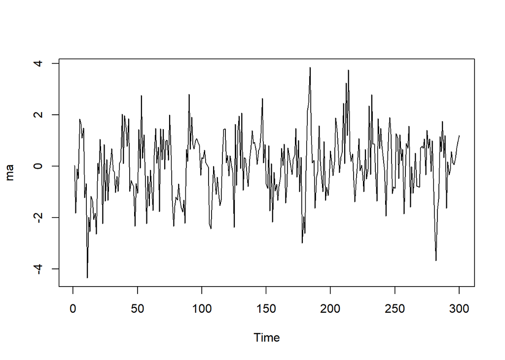

```r
ts.plot(ma)
```

Berdasarkan plot time series, terlihat bahwa data MA(2) yang dibangkitkan stasioner dalam rataan

### Plot ACF

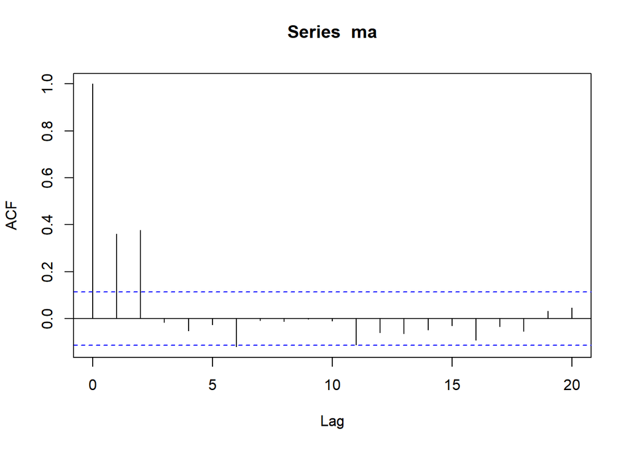

```r
acf(ma,lag.max = 20)
```

### Plot PACF

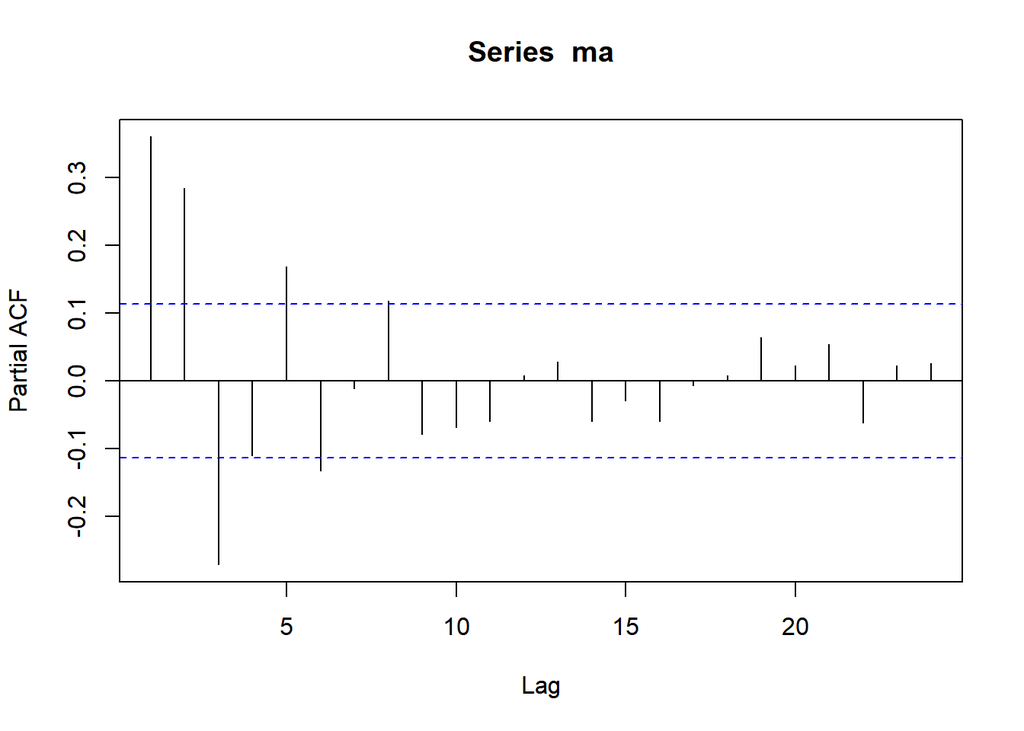

```r
pacf(ma)
```

Berdasarkan plot PACF tersebut, terlihat bahwa plot PACF cenderung *tails off* dan membentuk gelombang sinus

### Plot EACF

```r
TSA::eacf(ma)
```

```
## AR/MA
##   0 1 2 3 4 5 6 7 8 9 10 11 12 13
## 0 x x o o o x o o o o o  o  o  o
## 1 x x x o o x o o o o x  o  o  o
## 2 x x x x o x o o o o x  o  o  o
## 3 x x o x o x o o o o x  o  o  o
## 4 x x x o o x o o o o x  o  o  o
## 5 x x o x o o x o o o o  o  o  o
## 6 o x o o o o x x o o o  o  o  o
## 7 o x o o o o x o o o o  o  o  o
```

Berdasarkan pola segitiga nol pada plot EACF, terlihat bahwa segitiga nol berada pada ordo AR(0) dan ordo MA(2)

### Scatterplot Antar Lag

#### Korelasi antara $Y_t$ dengan $Y_{t-1}$

```r
#Yt
yt_ma1 <- ma[-1]
yt_ma1
```

```
##   [1] -1.8203328365 -0.1048133076 -0.4831169844  1.8315707983  1.6401161257
##   [6]  1.0922054741  1.4800023933 -1.2256418366 -0.6768859188 -4.3504595759
##  [11] -1.9899928107 -2.5322443745 -1.1635643253 -1.3531747789 -2.0654996710
##  [16] -1.8201522740 -2.6343975161  0.1177536943 -0.2923502497  1.0499033025
##  [21] -0.0006777566 -2.2352939589  0.8457765851 -1.3561326952  0.2546374708
##  [26] -1.3279918168 -0.3227505445  0.1711841241  0.6832536669 -0.1644475492
##  [31] -0.2151223708 -1.0198267689 -0.3987183036 -0.9846599609  0.1161664416
##  [36]  0.2148168055  2.0212685036  0.1040531047  1.9641476490  1.5180083942
##  [41]  0.7686619450  1.8461758921 -0.9739092449 -0.5599835262 -0.6918925391
##  [46] -0.7741963085 -2.3310141886 -0.6701787164 -1.0522183251  1.4226590303
##  [51] -0.0676410731  2.7587812403  0.3075495414  1.2185457461 -0.3491695822
##  [56] -2.2314306720 -0.3777871320 -1.5526148519 -0.1477621816 -0.7976548444
##  [61] -1.7224359875  0.4263950977  1.4742503098  0.1095369812  0.7356172582
##  [66] -1.7730817687  1.4501815646  0.2439037905  1.4356872968 -0.1190427361
##  [71]  0.9776084951  1.0201160169  0.2262907093  2.0017097320  0.4392636113
```

[output cut: 45 more lines]

```r
#Yt-1
yt_1_ma <- ma[-300]
yt_1_ma
```

```
##   [1]  0.0347802374 -1.8203328365 -0.1048133076 -0.4831169844  1.8315707983
##   [6]  1.6401161257  1.0922054741  1.4800023933 -1.2256418366 -0.6768859188
##  [11] -4.3504595759 -1.9899928107 -2.5322443745 -1.1635643253 -1.3531747789
##  [16] -2.0654996710 -1.8201522740 -2.6343975161  0.1177536943 -0.2923502497
##  [21]  1.0499033025 -0.0006777566 -2.2352939589  0.8457765851 -1.3561326952
##  [26]  0.2546374708 -1.3279918168 -0.3227505445  0.1711841241  0.6832536669
##  [31] -0.1644475492 -0.2151223708 -1.0198267689 -0.3987183036 -0.9846599609
##  [36]  0.1161664416  0.2148168055  2.0212685036  0.1040531047  1.9641476490
##  [41]  1.5180083942  0.7686619450  1.8461758921 -0.9739092449 -0.5599835262
##  [46] -0.6918925391 -0.7741963085 -2.3310141886 -0.6701787164 -1.0522183251
##  [51]  1.4226590303 -0.0676410731  2.7587812403  0.3075495414  1.2185457461
##  [56] -0.3491695822 -2.2314306720 -0.3777871320 -1.5526148519 -0.1477621816
##  [61] -0.7976548444 -1.7224359875  0.4263950977  1.4742503098  0.1095369812
##  [66]  0.7356172582 -1.7730817687  1.4501815646  0.2439037905  1.4356872968
##  [71] -0.1190427361  0.9776084951  1.0201160169  0.2262907093  2.0017097320
```

[output cut: 45 more lines]

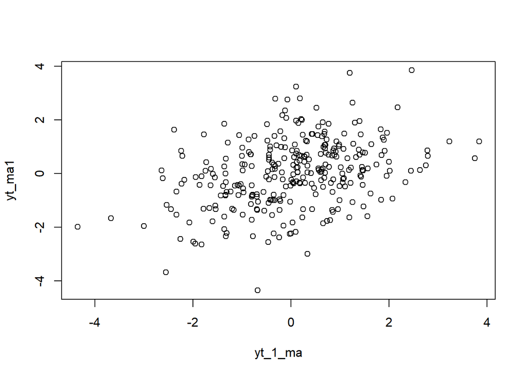

```r
plot(y=yt_ma1,x=yt_1_ma)
```

Berdasarkan scatterplot tersebut, terlihat bahwa terdapat hubungan positif antara $Y_t$ dengan $Y_{t-1}$. Hal ini sesuai dengan teori yang ada

```r
cor(yt_ma1,yt_1_ma)
```

```
## [1] 0.3609465
```

#### Korelasi antara $Y_t$ dengan $Y_{t-2}$

```r
#Yt
yt_ma2 <- ma[-c(1,2)]
yt_ma2
```

```
##   [1] -0.1048133076 -0.4831169844  1.8315707983  1.6401161257  1.0922054741
##   [6]  1.4800023933 -1.2256418366 -0.6768859188 -4.3504595759 -1.9899928107
##  [11] -2.5322443745 -1.1635643253 -1.3531747789 -2.0654996710 -1.8201522740
##  [16] -2.6343975161  0.1177536943 -0.2923502497  1.0499033025 -0.0006777566
##  [21] -2.2352939589  0.8457765851 -1.3561326952  0.2546374708 -1.3279918168
##  [26] -0.3227505445  0.1711841241  0.6832536669 -0.1644475492 -0.2151223708
##  [31] -1.0198267689 -0.3987183036 -0.9846599609  0.1161664416  0.2148168055
##  [36]  2.0212685036  0.1040531047  1.9641476490  1.5180083942  0.7686619450
##  [41]  1.8461758921 -0.9739092449 -0.5599835262 -0.6918925391 -0.7741963085
##  [46] -2.3310141886 -0.6701787164 -1.0522183251  1.4226590303 -0.0676410731
##  [51]  2.7587812403  0.3075495414  1.2185457461 -0.3491695822 -2.2314306720
##  [56] -0.3777871320 -1.5526148519 -0.1477621816 -0.7976548444 -1.7224359875
##  [61]  0.4263950977  1.4742503098  0.1095369812  0.7356172582 -1.7730817687
##  [66]  1.4501815646  0.2439037905  1.4356872968 -0.1190427361  0.9776084951
##  [71]  1.0201160169  0.2262907093  2.0017097320  0.4392636113 -1.3275192196
```

[output cut: 45 more lines]

```r
#Yt-2
yt_2_ma <- ma[-c(299,300)]
yt_2_ma
```

```
##   [1]  0.0347802374 -1.8203328365 -0.1048133076 -0.4831169844  1.8315707983
##   [6]  1.6401161257  1.0922054741  1.4800023933 -1.2256418366 -0.6768859188
##  [11] -4.3504595759 -1.9899928107 -2.5322443745 -1.1635643253 -1.3531747789
##  [16] -2.0654996710 -1.8201522740 -2.6343975161  0.1177536943 -0.2923502497
##  [21]  1.0499033025 -0.0006777566 -2.2352939589  0.8457765851 -1.3561326952
##  [26]  0.2546374708 -1.3279918168 -0.3227505445  0.1711841241  0.6832536669
##  [31] -0.1644475492 -0.2151223708 -1.0198267689 -0.3987183036 -0.9846599609
##  [36]  0.1161664416  0.2148168055  2.0212685036  0.1040531047  1.9641476490
##  [41]  1.5180083942  0.7686619450  1.8461758921 -0.9739092449 -0.5599835262
##  [46] -0.6918925391 -0.7741963085 -2.3310141886 -0.6701787164 -1.0522183251
##  [51]  1.4226590303 -0.0676410731  2.7587812403  0.3075495414  1.2185457461
##  [56] -0.3491695822 -2.2314306720 -0.3777871320 -1.5526148519 -0.1477621816
##  [61] -0.7976548444 -1.7224359875  0.4263950977  1.4742503098  0.1095369812
##  [66]  0.7356172582 -1.7730817687  1.4501815646  0.2439037905  1.4356872968
##  [71] -0.1190427361  0.9776084951  1.0201160169  0.2262907093  2.0017097320
```

[output cut: 45 more lines]

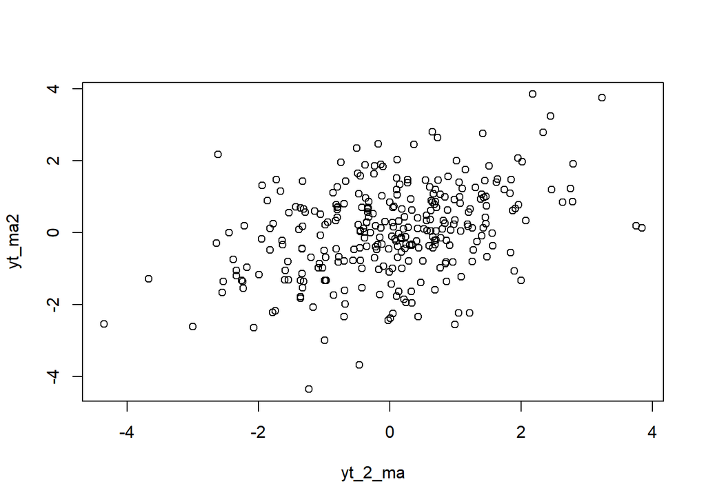

```r
plot(y=yt_ma2,x=yt_2_ma)
```

```r
cor(yt_ma2,yt_2_ma)
```

```
## [1] 0.379428
```

#### Korelasi antara $Y_t$ dengan $Y_{t-3}$

```r
#Yt
yt_ma3 <- ma[-c(1,2,3)]
yt_ma3
```

```
##   [1] -0.4831169844  1.8315707983  1.6401161257  1.0922054741  1.4800023933
##   [6] -1.2256418366 -0.6768859188 -4.3504595759 -1.9899928107 -2.5322443745
##  [11] -1.1635643253 -1.3531747789 -2.0654996710 -1.8201522740 -2.6343975161
##  [16]  0.1177536943 -0.2923502497  1.0499033025 -0.0006777566 -2.2352939589
##  [21]  0.8457765851 -1.3561326952  0.2546374708 -1.3279918168 -0.3227505445
##  [26]  0.1711841241  0.6832536669 -0.1644475492 -0.2151223708 -1.0198267689
##  [31] -0.3987183036 -0.9846599609  0.1161664416  0.2148168055  2.0212685036
##  [36]  0.1040531047  1.9641476490  1.5180083942  0.7686619450  1.8461758921
##  [41] -0.9739092449 -0.5599835262 -0.6918925391 -0.7741963085 -2.3310141886
##  [46] -0.6701787164 -1.0522183251  1.4226590303 -0.0676410731  2.7587812403
##  [51]  0.3075495414  1.2185457461 -0.3491695822 -2.2314306720 -0.3777871320
##  [56] -1.5526148519 -0.1477621816 -0.7976548444 -1.7224359875  0.4263950977
##  [61]  1.4742503098  0.1095369812  0.7356172582 -1.7730817687  1.4501815646
##  [66]  0.2439037905  1.4356872968 -0.1190427361  0.9776084951  1.0201160169
##  [71]  0.2262907093  2.0017097320  0.4392636113 -1.3275192196 -2.3323125150
```

[output cut: 45 more lines]

```r
#Yt-2
yt_3_ma <- ma[-c(298,299,300)]
yt_3_ma
```

```
##   [1]  0.0347802374 -1.8203328365 -0.1048133076 -0.4831169844  1.8315707983
##   [6]  1.6401161257  1.0922054741  1.4800023933 -1.2256418366 -0.6768859188
##  [11] -4.3504595759 -1.9899928107 -2.5322443745 -1.1635643253 -1.3531747789
##  [16] -2.0654996710 -1.8201522740 -2.6343975161  0.1177536943 -0.2923502497
##  [21]  1.0499033025 -0.0006777566 -2.2352939589  0.8457765851 -1.3561326952
##  [26]  0.2546374708 -1.3279918168 -0.3227505445  0.1711841241  0.6832536669
##  [31] -0.1644475492 -0.2151223708 -1.0198267689 -0.3987183036 -0.9846599609
##  [36]  0.1161664416  0.2148168055  2.0212685036  0.1040531047  1.9641476490
##  [41]  1.5180083942  0.7686619450  1.8461758921 -0.9739092449 -0.5599835262
##  [46] -0.6918925391 -0.7741963085 -2.3310141886 -0.6701787164 -1.0522183251
##  [51]  1.4226590303 -0.0676410731  2.7587812403  0.3075495414  1.2185457461
##  [56] -0.3491695822 -2.2314306720 -0.3777871320 -1.5526148519 -0.1477621816
##  [61] -0.7976548444 -1.7224359875  0.4263950977  1.4742503098  0.1095369812
##  [66]  0.7356172582 -1.7730817687  1.4501815646  0.2439037905  1.4356872968
##  [71] -0.1190427361  0.9776084951  1.0201160169  0.2262907093  2.0017097320
```

[output cut: 45 more lines]

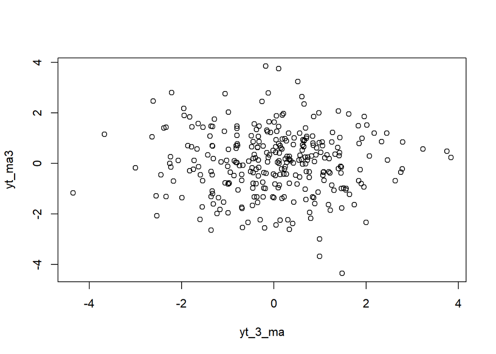

```r
plot(y=yt_ma3,x=yt_3_ma)
```

Berdasarkan scatterplot tersebut, terlihat bahwa cenderung tidak terdapat hubungan antara $Y_t$ dengan $Y_{t-3}$.

```r
cor(yt_ma3,yt_3_ma)
```

```
## [1] -0.01689939
```

Korelasi antara $Y_t$ dengan $Y_{t-3}$ hasil simulasi mendekati teori yang ada yaitu 0.

## Proses AR

Proses AR dapat dituliskan sebagai berikut:

$$y_{t} = c + e_t + \phi_{1}Y_{t-1} +
\phi_{2}Y_{t-2} + \dots + \phi_{q}Y_{t-q} = c+{e_t+\sum_{i=1}^p
\phi_iY_{t-i}}$$
Terlihat bahwa $Y_t$ berperan penting dalam pembangkitan proses AR.

## Pembangkitan Proses AR

Akan dicoba membangkitkan proses AR paling sederhana, yaitu AR(2) dengan $\phi = 0.5 dan 0.2$ sebanyak 300 observasi dan $c=0$.

```r
set.seed(052)
```

Nilai-nilai selanjutnya dapat dicari melalui *loop*. Bentuk loop dapat dilihat dari rumus AR(2) yang hendak dibangkitkan:

$$Y_t = e_t+0.5Y_{t-1}+0.2Y_{t-2}$$

```r
n<-length(wn)
n
```

```
## [1] 300
```

```r
ar <- c(2:n)
for (i in 3:n) {ar[i]<-wn[i]+0.5*ar[i-1]+0.2*ar[i-2]}
ar
```

```
##   [1]  2.000000000  3.000000000  2.502451685  2.219327886  2.933013250
##   [6]  2.800483514  1.929289974  2.493699069  0.054015401 -0.101035981
##  [11] -3.192245811 -1.969240455 -2.122631082 -2.207157068 -2.280745139
##  [16] -2.895051437 -2.746943806 -3.461623610 -1.052828868 -1.096553233
##  [21] -0.494236476 -0.646260561 -2.744102413  0.381222207 -1.074077382
##  [26] -1.049324893 -1.402536680 -0.615541974 -0.137495482  0.133729588
##  [31] -0.525785846 -0.420560193 -0.922407834 -0.590598119 -1.082145381
##  [36] -0.274910673  0.068638589  1.601027478  0.016104633  1.638646000
##  [41]  2.295279140  0.868703717  2.098608472  0.131054452 -0.361058866
##  [46]  0.147506349 -0.385600192 -2.520551313 -0.832388461 -0.760174220
##  [51]  0.509037779 -0.483476224  2.219873243  0.728445560  0.724779222
##  [56]  0.363153914 -1.796877023 -0.267276045 -0.994995058 -0.833041277
##  [61] -0.999150101 -2.065913990 -0.016321373  1.406158979 -0.651528174
##  [66]  0.135120844 -1.096882202  1.234627547  0.559905526  0.844151605
##  [71]  0.190923923  1.188789972  1.488776502  0.311259648  2.209731456
```

[output cut: 45 more lines]

Selain menggunakan cara di atas, pembangkitan proses AR dapat dilakukan dengan fungsi `arima.sim()` sebagai berikut.

```r
ar2 <- arima.sim(list(order=c(2,0,0), ar=c(0.5,0.2)), n=300)
ar2
```

```
## Time Series:
## Start = 1
## End = 300
## Frequency = 1
##   [1]  0.332878968 -0.740537866  0.124361462 -0.486728287 -0.824179495
##   [6] -0.960113041 -1.411730915 -0.787728473  0.018376171 -0.368314790
##  [11]  0.772219015  0.295079181 -0.026894514  0.934292638  0.671709908
##  [16]  1.803677016  1.666526616  1.118577506  0.619055277 -0.318468917
##  [21]  2.292087012  1.082509719  0.754611857  0.767752365 -0.152442493
##  [26]  0.872444778  1.055894440 -0.549548778 -0.732169760  0.775088234
##  [31] -1.320170229 -1.525880047 -1.872602800 -0.409548799 -1.199673414
##  [36] -0.481865138 -0.366278189 -0.941847781 -1.216677204 -2.290751710
##  [41] -0.917443980 -1.628709867 -0.557509325 -0.569216798 -0.334135352
##  [46] -0.666555371 -1.406670846  0.053889403 -0.447055186 -1.121936182
##  [51] -1.850890111 -0.612032359 -1.233343855 -0.862798147 -0.397342005
```

[output cut: 49 more lines]

## Karakteristik AR(2)

### Plot Time Series

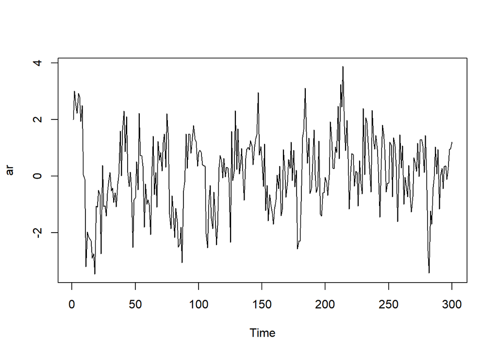

```r
ts.plot(ar)
```

Berdasarkan plot time series tersebut terlihat bahwa data cenderung stasioner pada rataan

### Plot ACF

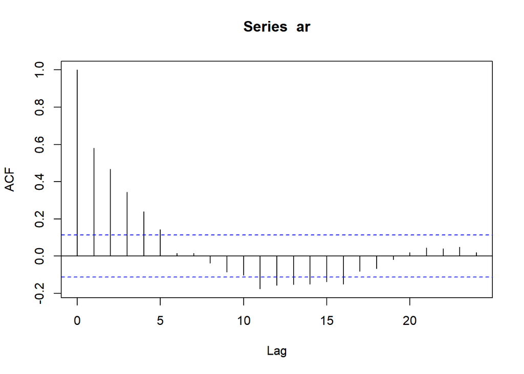

```r
acf(ar)
```

Berdasarkan plot ACF tersebut terlihat bahwa plot ACF cenderung *tails off* dan cenderung membentuk pola grafik sinus

### Plot PACF

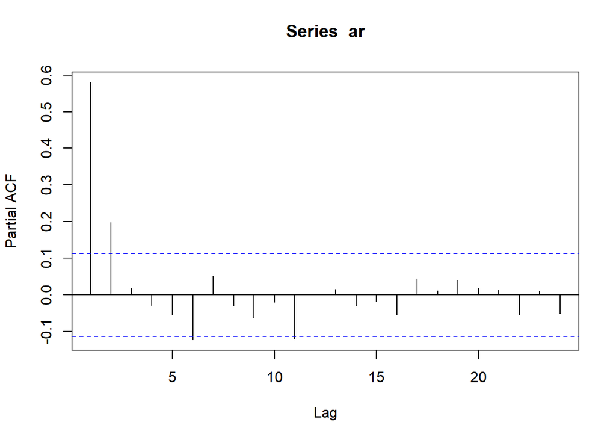

```r
pacf(ar)
```

### Plot EACF

```r
TSA::eacf(ar)
```

```
## AR/MA
##   0 1 2 3 4 5 6 7 8 9 10 11 12 13
## 0 x x x x x o o o o o x  x  x  x
## 1 x o o o x x o o o o x  o  o  o
## 2 o x o o o o o o o o x  o  o  o
## 3 x o o o o o o o o o x  o  o  o
## 4 x o o o o o o o o o o  o  o  o
## 5 x o x x x o o o o o o  o  o  o
## 6 x o x x x o o o o o o  o  o  o
## 7 x o x o x x o o o o o  o  o  o
```

### Scatterplot Antar Lag

#### Korelasi antara $Y_t$ dengan $Y_{t-1}$

```r
#Yt
yt_ar1 <- ar[-1]
yt_ar1
```

```
##   [1]  3.000000000  2.502451685  2.219327886  2.933013250  2.800483514
##   [6]  1.929289974  2.493699069  0.054015401 -0.101035981 -3.192245811
##  [11] -1.969240455 -2.122631082 -2.207157068 -2.280745139 -2.895051437
##  [16] -2.746943806 -3.461623610 -1.052828868 -1.096553233 -0.494236476
##  [21] -0.646260561 -2.744102413  0.381222207 -1.074077382 -1.049324893
##  [26] -1.402536680 -0.615541974 -0.137495482  0.133729588 -0.525785846
##  [31] -0.420560193 -0.922407834 -0.590598119 -1.082145381 -0.274910673
##  [36]  0.068638589  1.601027478  0.016104633  1.638646000  2.295279140
##  [41]  0.868703717  2.098608472  0.131054452 -0.361058866  0.147506349
##  [46] -0.385600192 -2.520551313 -0.832388461 -0.760174220  0.509037779
##  [51] -0.483476224  2.219873243  0.728445560  0.724779222  0.363153914
##  [56] -1.796877023 -0.267276045 -0.994995058 -0.833041277 -0.999150101
##  [61] -2.065913990 -0.016321373  1.406158979 -0.651528174  0.135120844
##  [66] -1.096882202  1.234627547  0.559905526  0.844151605  0.190923923
##  [71]  1.188789972  1.488776502  0.311259648  2.209731456  1.306374695
```

[output cut: 45 more lines]

```r
#Yt-1
yt_1_ar <- ar[-300]
yt_1_ar
```

```
##   [1]  2.000000000  3.000000000  2.502451685  2.219327886  2.933013250
##   [6]  2.800483514  1.929289974  2.493699069  0.054015401 -0.101035981
##  [11] -3.192245811 -1.969240455 -2.122631082 -2.207157068 -2.280745139
##  [16] -2.895051437 -2.746943806 -3.461623610 -1.052828868 -1.096553233
##  [21] -0.494236476 -0.646260561 -2.744102413  0.381222207 -1.074077382
##  [26] -1.049324893 -1.402536680 -0.615541974 -0.137495482  0.133729588
##  [31] -0.525785846 -0.420560193 -0.922407834 -0.590598119 -1.082145381
##  [36] -0.274910673  0.068638589  1.601027478  0.016104633  1.638646000
##  [41]  2.295279140  0.868703717  2.098608472  0.131054452 -0.361058866
##  [46]  0.147506349 -0.385600192 -2.520551313 -0.832388461 -0.760174220
##  [51]  0.509037779 -0.483476224  2.219873243  0.728445560  0.724779222
##  [56]  0.363153914 -1.796877023 -0.267276045 -0.994995058 -0.833041277
##  [61] -0.999150101 -2.065913990 -0.016321373  1.406158979 -0.651528174
##  [66]  0.135120844 -1.096882202  1.234627547  0.559905526  0.844151605
##  [71]  0.190923923  1.188789972  1.488776502  0.311259648  2.209731456
```

[output cut: 45 more lines]

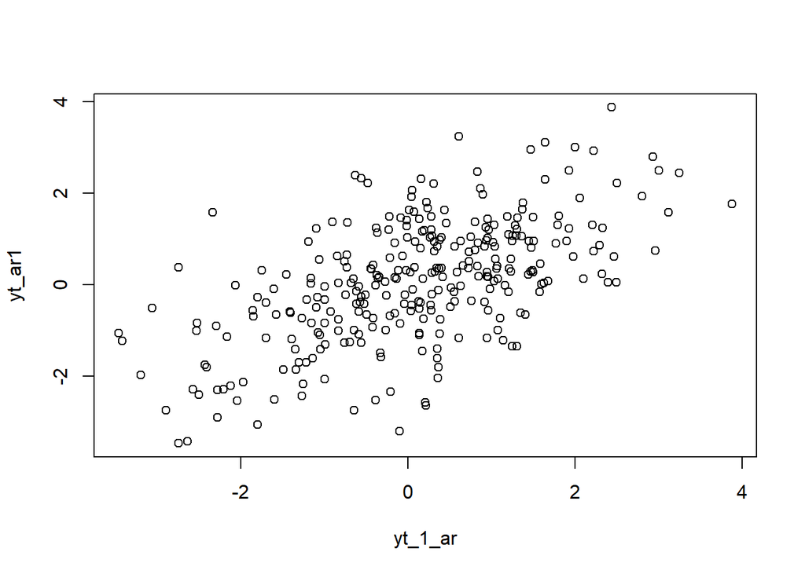

```r
plot(y=yt_ar1,x=yt_1_ar)
```

Berdasarkan scatterplot tersebut, terlihat bahwa terdapat hubungan positif antara $Y_t$ dengan $Y_{t-1}$. Hal ini sesuai dengan teori yang ada

```r
cor(yt_ar1,yt_1_ar)
```

```
## [1] 0.5828784
```

#### Korelasi antara $Y_t$ dengan $Y_{t-2}$

```r
#Yt
yt_ar2 <- ar[-c(1,2)]
yt_ar2
```

```
##   [1]  2.502451685  2.219327886  2.933013250  2.800483514  1.929289974
##   [6]  2.493699069  0.054015401 -0.101035981 -3.192245811 -1.969240455
##  [11] -2.122631082 -2.207157068 -2.280745139 -2.895051437 -2.746943806
##  [16] -3.461623610 -1.052828868 -1.096553233 -0.494236476 -0.646260561
##  [21] -2.744102413  0.381222207 -1.074077382 -1.049324893 -1.402536680
##  [26] -0.615541974 -0.137495482  0.133729588 -0.525785846 -0.420560193
##  [31] -0.922407834 -0.590598119 -1.082145381 -0.274910673  0.068638589
##  [36]  1.601027478  0.016104633  1.638646000  2.295279140  0.868703717
##  [41]  2.098608472  0.131054452 -0.361058866  0.147506349 -0.385600192
##  [46] -2.520551313 -0.832388461 -0.760174220  0.509037779 -0.483476224
##  [51]  2.219873243  0.728445560  0.724779222  0.363153914 -1.796877023
##  [56] -0.267276045 -0.994995058 -0.833041277 -0.999150101 -2.065913990
##  [61] -0.016321373  1.406158979 -0.651528174  0.135120844 -1.096882202
##  [66]  1.234627547  0.559905526  0.844151605  0.190923923  1.188789972
##  [71]  1.488776502  0.311259648  2.209731456  1.306374695 -1.341896195
```

[output cut: 45 more lines]

```r
#Yt-2
yt_2_ar <- ar[-c(299,300)]
yt_2_ar
```

```
##   [1]  2.000000000  3.000000000  2.502451685  2.219327886  2.933013250
##   [6]  2.800483514  1.929289974  2.493699069  0.054015401 -0.101035981
##  [11] -3.192245811 -1.969240455 -2.122631082 -2.207157068 -2.280745139
##  [16] -2.895051437 -2.746943806 -3.461623610 -1.052828868 -1.096553233
##  [21] -0.494236476 -0.646260561 -2.744102413  0.381222207 -1.074077382
##  [26] -1.049324893 -1.402536680 -0.615541974 -0.137495482  0.133729588
##  [31] -0.525785846 -0.420560193 -0.922407834 -0.590598119 -1.082145381
##  [36] -0.274910673  0.068638589  1.601027478  0.016104633  1.638646000
##  [41]  2.295279140  0.868703717  2.098608472  0.131054452 -0.361058866
##  [46]  0.147506349 -0.385600192 -2.520551313 -0.832388461 -0.760174220
##  [51]  0.509037779 -0.483476224  2.219873243  0.728445560  0.724779222
##  [56]  0.363153914 -1.796877023 -0.267276045 -0.994995058 -0.833041277
##  [61] -0.999150101 -2.065913990 -0.016321373  1.406158979 -0.651528174
##  [66]  0.135120844 -1.096882202  1.234627547  0.559905526  0.844151605
##  [71]  0.190923923  1.188789972  1.488776502  0.311259648  2.209731456
```

[output cut: 45 more lines]

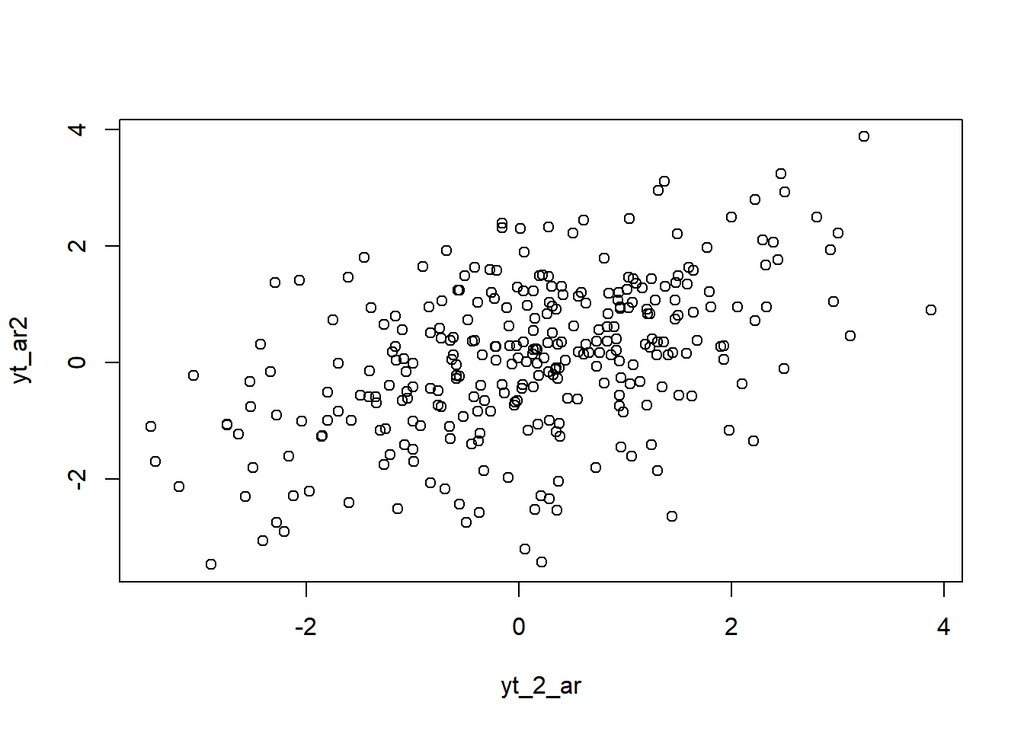

```r
plot(y=yt_ar2,x=yt_2_ar)
```

Berdasarkan scatterplot tersebut, terlihat bahwa terdapat hubungan positif antara $Y_t$ dengan $Y_{t-2}$. Hal ini sesuai dengan teori yang ada

```r
cor(yt_ar2,yt_2_ar)
```

```
## [1] 0.4743504
```

#### Korelasi antara $Y_t$ dengan $Y_{t-3}$

```r
#Yt
yt_ar3 <- ar[-c(1,2,3)]
yt_ar3
```

```
##   [1]  2.219327886  2.933013250  2.800483514  1.929289974  2.493699069
##   [6]  0.054015401 -0.101035981 -3.192245811 -1.969240455 -2.122631082
##  [11] -2.207157068 -2.280745139 -2.895051437 -2.746943806 -3.461623610
##  [16] -1.052828868 -1.096553233 -0.494236476 -0.646260561 -2.744102413
##  [21]  0.381222207 -1.074077382 -1.049324893 -1.402536680 -0.615541974
##  [26] -0.137495482  0.133729588 -0.525785846 -0.420560193 -0.922407834
##  [31] -0.590598119 -1.082145381 -0.274910673  0.068638589  1.601027478
##  [36]  0.016104633  1.638646000  2.295279140  0.868703717  2.098608472
##  [41]  0.131054452 -0.361058866  0.147506349 -0.385600192 -2.520551313
##  [46] -0.832388461 -0.760174220  0.509037779 -0.483476224  2.219873243
##  [51]  0.728445560  0.724779222  0.363153914 -1.796877023 -0.267276045
##  [56] -0.994995058 -0.833041277 -0.999150101 -2.065913990 -0.016321373
##  [61]  1.406158979 -0.651528174  0.135120844 -1.096882202  1.234627547
##  [66]  0.559905526  0.844151605  0.190923923  1.188789972  1.488776502
##  [71]  0.311259648  2.209731456  1.306374695 -1.341896195 -1.850727962
```

[output cut: 45 more lines]

```r
#Yt-3
yt_3_ar <- ar[-c(298,299,300)]
yt_3_ar
```

```
##   [1]  2.000000000  3.000000000  2.502451685  2.219327886  2.933013250
##   [6]  2.800483514  1.929289974  2.493699069  0.054015401 -0.101035981
##  [11] -3.192245811 -1.969240455 -2.122631082 -2.207157068 -2.280745139
##  [16] -2.895051437 -2.746943806 -3.461623610 -1.052828868 -1.096553233
##  [21] -0.494236476 -0.646260561 -2.744102413  0.381222207 -1.074077382
##  [26] -1.049324893 -1.402536680 -0.615541974 -0.137495482  0.133729588
##  [31] -0.525785846 -0.420560193 -0.922407834 -0.590598119 -1.082145381
##  [36] -0.274910673  0.068638589  1.601027478  0.016104633  1.638646000
##  [41]  2.295279140  0.868703717  2.098608472  0.131054452 -0.361058866
##  [46]  0.147506349 -0.385600192 -2.520551313 -0.832388461 -0.760174220
##  [51]  0.509037779 -0.483476224  2.219873243  0.728445560  0.724779222
##  [56]  0.363153914 -1.796877023 -0.267276045 -0.994995058 -0.833041277
##  [61] -0.999150101 -2.065913990 -0.016321373  1.406158979 -0.651528174
##  [66]  0.135120844 -1.096882202  1.234627547  0.559905526  0.844151605
##  [71]  0.190923923  1.188789972  1.488776502  0.311259648  2.209731456
```

[output cut: 45 more lines]

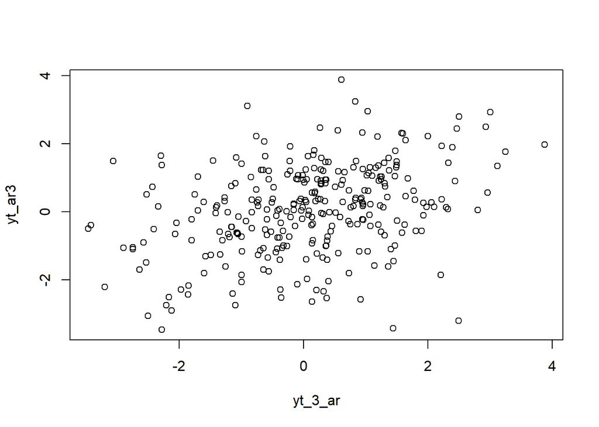

```r
plot(y=yt_ar3,x=yt_3_ar)
```

Berdasarkan scatterplot tersebut, terlihat bahwa terdapat hubungan positif antara $Y_t$ dengan $Y_{t-3}$. Hal ini sesuai dengan teori yang ada

```r
cor(yt_ar3,yt_3_ar)
```

```
## [1] 0.3505896
```

## Fungsi pembangkitan ARMA

```r
set.seed(052)
n = length(wn)
phi1 = 0.5
phi2 = 0.2
theta1 = 0.4
theta2 = 0.6

y.arma=c(1:n)
for (i in 3:n){y.arma[i] = phi1*y.arma[i-1] + phi2*y.arma[i-2] + theta1*wn[i-1]+ theta2*wn[i-2]+ wn[i]}
y.arma
```

```
##   [1]  1.0000000000  2.0000000000  1.0951866924  0.4644763619  2.2828463177
##   [6]  2.8744345570  2.9859920161  3.5478853128  1.1454992230  0.6054407552
##  [11] -3.8186393537 -3.7782243365 -5.1850844135 -4.5117513994 -4.6460673613
##  [16] -5.2908836316 -5.3948075620 -6.3899780234 -4.1561968298 -3.6484442693
##  [21] -1.6055581981 -1.5331457095 -3.3229784532 -1.1223417834 -2.5818992776
##  [26] -1.2607805247 -2.4747619347 -1.8122876168 -1.2299120713 -0.2941598921
##  [31] -0.5575099095 -0.5527093040 -1.4076834028 -1.2131018658 -1.8727475744
##  [36] -1.0628277187 -0.6911465688  1.4631296754  0.6973886286  2.6054678984
##  [41]  2.9602200691  2.7698655592  3.8231526855  1.4916402097  0.9504671157
##  [46]  0.0816690607 -0.5432683550 -2.5863145540 -2.0719896644 -2.6054760681
##  [51] -0.2944769366 -0.7359747550  2.3318984754  1.3263038281  2.3480773552
##  [56]  1.0901298610 -1.2167502705 -0.7681362950 -2.1800330535 -1.3914059674
##  [61] -1.9293644388 -2.9653994004 -1.4421774902  0.1600816846 -0.0988576745
##  [66]  0.7182047579 -1.4337509247  0.8769470538  0.3956271325  1.8088902739
##  [71]  0.8645278274  1.7716504636  2.0788468142  1.6200442091  3.2275011993
```

[output cut: 45 more lines]

Pembangkitan ARMA(p,q) juga dapat dilakukan dengan fungsi `arima.sim` sebagai berikut.

```r
arma22 <- arima.sim(list(order=c(2,0,2), ar =c(0.5,0.2), ma =c(0.4,0.6)), n=300)
arma22
```

```
## Time Series:
## Start = 1
## End = 300
## Frequency = 1
##   [1]  0.02886312 -0.88055214 -0.94367891 -1.58138344 -2.28994964 -1.92823389
##   [7] -1.14355954 -0.83345334  0.63603168  0.38306396  0.55453417  1.10063235
##  [13]  1.02932838  2.63296563  2.79104553  2.86741125  2.06641513  0.60030951
##  [19]  2.53614010  1.80826888  2.56287230  1.71910625  0.60742810  1.27212113
##  [25]  1.31340832  0.39627698 -0.31845175  0.15249171 -1.44943630 -1.58889482
##  [31] -3.27505667 -2.07411773 -2.48705445 -1.20746366 -1.27882820 -1.37747807
##  [37] -1.81318317 -3.34253122 -2.56375095 -3.37013846 -1.75945964 -1.76944643
##  [43] -0.89632765 -1.14173958 -1.87377420 -0.90871215 -1.26950193 -1.26842461
##  [49] -2.56789769 -2.02555011 -2.58869086 -1.72335510 -1.48246758 -1.85804676
##  [55] -2.16162518 -1.35327152 -0.96685769  0.82980147  0.40701413  0.86526823
##  [61] -0.14113773  1.63380983  2.51408688  2.26023665  0.57041029  1.35903962
```

[output cut: 39 more lines]

## Karakteristik ARMA(2,2)

### Plot Time Series

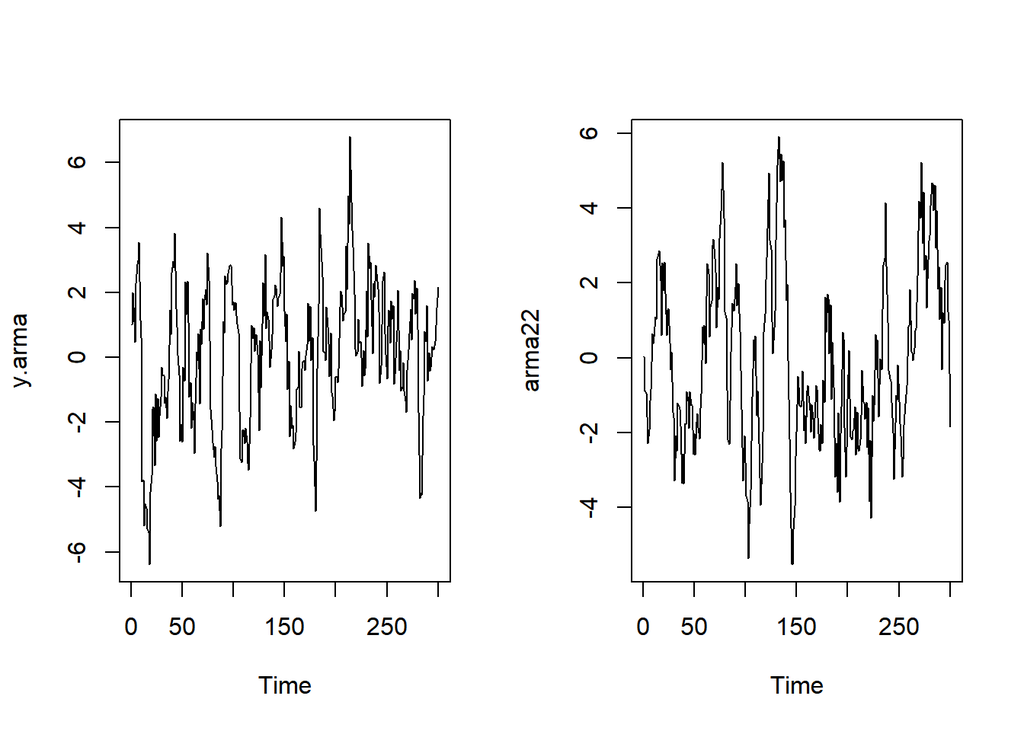

```r
par(mfrow = c(1, 2))
ts.plot(y.arma)
ts.plot(arma22)
```

```r
par(mfrow = c(1, 1))
```

Berdasarkan plot time series tersebut, terlihat bahwa model ARMA(2,2) cenderung stasioner dalam rataan

### Plot ACF

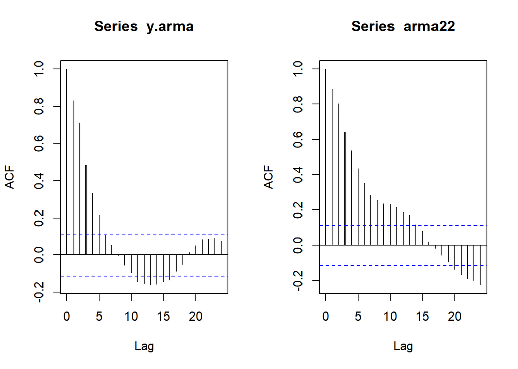

```r
par(mfrow = c(1, 2))
acf(y.arma)
acf(arma22)
```

```r
par(mfrow = c(1, 1))
```

### Plot PACF

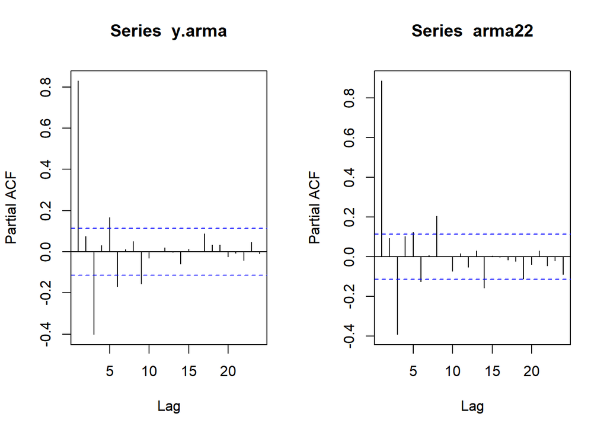

```r
par(mfrow = c(1, 2))
pacf(y.arma)
pacf(arma22)
```

```r
par(mfrow = c(1, 1))
```

### Plot EACF

```r
TSA::eacf(y.arma)
```

```
## AR/MA
##   0 1 2 3 4 5 6 7 8 9 10 11 12 13
## 0 x x x x x o o o o o x  x  x  x
## 1 o x o o x o o o o o x  o  o  o
## 2 x x o o o o o o o o x  o  o  o
## 3 o x x o x o o o o o x  o  o  o
## 4 x x x x x o o o o o o  o  o  o
## 5 x x x o o o o o o o x  o  o  o
## 6 o x x o o o o o o o o  o  o  o
## 7 o o x x o o x o o o o  o  o  o
```

```r
TSA::eacf(arma22)
```

```
## AR/MA
##   0 1 2 3 4 5 6 7 8 9 10 11 12 13
## 0 x x x x x x x x x x x  x  x  o
## 1 o x x o o o x o o o o  o  x  o
## 2 x x o o o o o o o o o  o  x  o
## 3 x x x o o o o o o o o  o  x  o
## 4 x x o o o o o o o o o  o  o  o
## 5 x x o o o x x o o o o  o  o  o
## 6 o x x o x o x o o o o  o  x  o
## 7 o x x o x o x o o o o  o  x  o
```

### Scatterplot Antar Lag

#### Korelasi antara $Y_t$ dengan $Y_{t-1}$

```r
#Yt
yt_arma1 <- arma22[-1]
yt_arma1
```

```
##   [1] -0.88055214 -0.94367891 -1.58138344 -2.28994964 -1.92823389 -1.14355954
##   [7] -0.83345334  0.63603168  0.38306396  0.55453417  1.10063235  1.02932838
##  [13]  2.63296563  2.79104553  2.86741125  2.06641513  0.60030951  2.53614010
##  [19]  1.80826888  2.56287230  1.71910625  0.60742810  1.27212113  1.31340832
##  [25]  0.39627698 -0.31845175  0.15249171 -1.44943630 -1.58889482 -3.27505667
##  [31] -2.07411773 -2.48705445 -1.20746366 -1.27882820 -1.37747807 -1.81318317
##  [37] -3.34253122 -2.56375095 -3.37013846 -1.75945964 -1.76944643 -0.89632765
##  [43] -1.14173958 -1.87377420 -0.90871215 -1.26950193 -1.26842461 -2.56789769
##  [49] -2.02555011 -2.58869086 -1.72335510 -1.48246758 -1.85804676 -2.16162518
##  [55] -1.35327152 -0.96685769  0.82980147  0.40701413  0.86526823 -0.14113773
##  [61]  1.63380983  2.51408688  2.26023665  0.57041029  1.35903962  1.51656738
##  [67]  3.01736633  3.16981823  2.66921273  2.29010699  0.81220402  1.87804810
##  [73]  1.55973730  3.18323889  3.92334420  4.50758863  5.22155611  3.74187502
##  [79]  1.23654155  1.07436541 -0.86593264 -2.17661277 -2.30976194 -1.13972915
##  [85]  0.15367373  1.46040238  1.31998074  1.25149834  1.88010446  2.52214202
```

[output cut: 35 more lines]

```r
#Yt-1
yt_1_arma <- arma22[-300]
yt_1_arma
```

```
##   [1]  0.02886312 -0.88055214 -0.94367891 -1.58138344 -2.28994964 -1.92823389
##   [7] -1.14355954 -0.83345334  0.63603168  0.38306396  0.55453417  1.10063235
##  [13]  1.02932838  2.63296563  2.79104553  2.86741125  2.06641513  0.60030951
##  [19]  2.53614010  1.80826888  2.56287230  1.71910625  0.60742810  1.27212113
##  [25]  1.31340832  0.39627698 -0.31845175  0.15249171 -1.44943630 -1.58889482
##  [31] -3.27505667 -2.07411773 -2.48705445 -1.20746366 -1.27882820 -1.37747807
##  [37] -1.81318317 -3.34253122 -2.56375095 -3.37013846 -1.75945964 -1.76944643
##  [43] -0.89632765 -1.14173958 -1.87377420 -0.90871215 -1.26950193 -1.26842461
##  [49] -2.56789769 -2.02555011 -2.58869086 -1.72335510 -1.48246758 -1.85804676
##  [55] -2.16162518 -1.35327152 -0.96685769  0.82980147  0.40701413  0.86526823
##  [61] -0.14113773  1.63380983  2.51408688  2.26023665  0.57041029  1.35903962
##  [67]  1.51656738  3.01736633  3.16981823  2.66921273  2.29010699  0.81220402
##  [73]  1.87804810  1.55973730  3.18323889  3.92334420  4.50758863  5.22155611
##  [79]  3.74187502  1.23654155  1.07436541 -0.86593264 -2.17661277 -2.30976194
##  [85] -1.13972915  0.15367373  1.46040238  1.31998074  1.25149834  1.88010446
```

[output cut: 35 more lines]

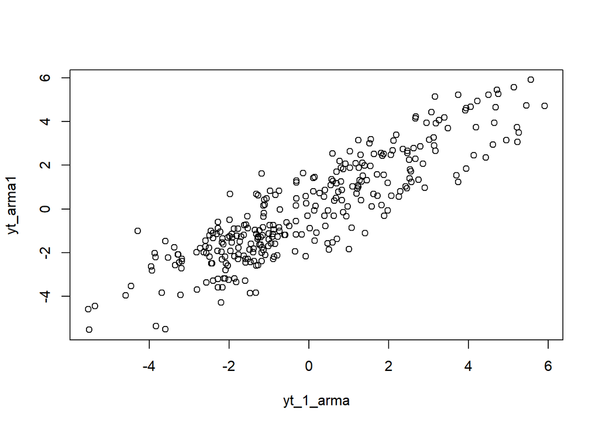

```r
plot(y=yt_arma1,x=yt_1_arma)
```

Berdasarkan scatterplot tersebut, terlihat bahwa terdapat hubungan positif antara $Y_t$ dengan $Y_{t-1}$. Hal ini sesuai dengan teori yang ada

```r
cor(yt_arma1,yt_1_arma)
```

```
## [1] 0.8855643
```

Korelasi antara $Y_t$ dengan $Y_{t-1}$ dari hasil simulasi mendekati perhitungan teoritis.

#### Korelasi antara $Y_t$ dengan $Y_{t-2}$

```r
#Yt
yt_arma2 <- arma22[-c(1,2)]
yt_arma2
```

```
##   [1] -0.94367891 -1.58138344 -2.28994964 -1.92823389 -1.14355954 -0.83345334
##   [7]  0.63603168  0.38306396  0.55453417  1.10063235  1.02932838  2.63296563
##  [13]  2.79104553  2.86741125  2.06641513  0.60030951  2.53614010  1.80826888
##  [19]  2.56287230  1.71910625  0.60742810  1.27212113  1.31340832  0.39627698
##  [25] -0.31845175  0.15249171 -1.44943630 -1.58889482 -3.27505667 -2.07411773
##  [31] -2.48705445 -1.20746366 -1.27882820 -1.37747807 -1.81318317 -3.34253122
##  [37] -2.56375095 -3.37013846 -1.75945964 -1.76944643 -0.89632765 -1.14173958
##  [43] -1.87377420 -0.90871215 -1.26950193 -1.26842461 -2.56789769 -2.02555011
##  [49] -2.58869086 -1.72335510 -1.48246758 -1.85804676 -2.16162518 -1.35327152
##  [55] -0.96685769  0.82980147  0.40701413  0.86526823 -0.14113773  1.63380983
##  [61]  2.51408688  2.26023665  0.57041029  1.35903962  1.51656738  3.01736633
##  [67]  3.16981823  2.66921273  2.29010699  0.81220402  1.87804810  1.55973730
##  [73]  3.18323889  3.92334420  4.50758863  5.22155611  3.74187502  1.23654155
##  [79]  1.07436541 -0.86593264 -2.17661277 -2.30976194 -1.13972915  0.15367373
##  [85]  1.46040238  1.31998074  1.25149834  1.88010446  2.52214202  1.40427084
```

[output cut: 35 more lines]

```r
#Yt-2
yt_2_arma <- arma22[-c(299,300)]
yt_2_arma
```

```
##   [1]  0.02886312 -0.88055214 -0.94367891 -1.58138344 -2.28994964 -1.92823389
##   [7] -1.14355954 -0.83345334  0.63603168  0.38306396  0.55453417  1.10063235
##  [13]  1.02932838  2.63296563  2.79104553  2.86741125  2.06641513  0.60030951
##  [19]  2.53614010  1.80826888  2.56287230  1.71910625  0.60742810  1.27212113
##  [25]  1.31340832  0.39627698 -0.31845175  0.15249171 -1.44943630 -1.58889482
##  [31] -3.27505667 -2.07411773 -2.48705445 -1.20746366 -1.27882820 -1.37747807
##  [37] -1.81318317 -3.34253122 -2.56375095 -3.37013846 -1.75945964 -1.76944643
##  [43] -0.89632765 -1.14173958 -1.87377420 -0.90871215 -1.26950193 -1.26842461
##  [49] -2.56789769 -2.02555011 -2.58869086 -1.72335510 -1.48246758 -1.85804676
##  [55] -2.16162518 -1.35327152 -0.96685769  0.82980147  0.40701413  0.86526823
##  [61] -0.14113773  1.63380983  2.51408688  2.26023665  0.57041029  1.35903962
##  [67]  1.51656738  3.01736633  3.16981823  2.66921273  2.29010699  0.81220402
##  [73]  1.87804810  1.55973730  3.18323889  3.92334420  4.50758863  5.22155611
##  [79]  3.74187502  1.23654155  1.07436541 -0.86593264 -2.17661277 -2.30976194
##  [85] -1.13972915  0.15367373  1.46040238  1.31998074  1.25149834  1.88010446
```

[output cut: 35 more lines]

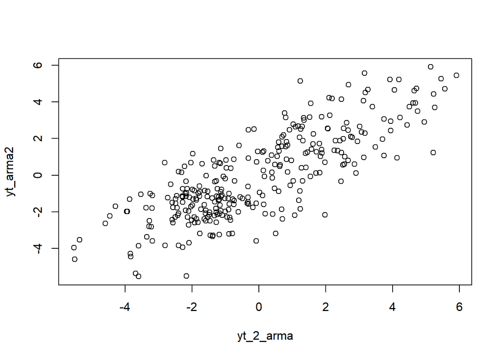

```r
plot(y=yt_arma2,x=yt_2_arma)
```

Berdasarkan scatterplot tersebut, terlihat bahwa terdapat hubungan positif antara $Y_t$ dengan $Y_{t-2}$. Hal ini sesuai dengan teori yang ada

```r
cor(yt_arma2,yt_2_arma)
```

```
## [1] 0.8038468
```

Korelasi antara $Y_t$ dengan $Y_{t-2}$ dari hasil simulasi mendekati perhitungan teoritis.

#### Korelasi antara $Y_t$ dengan $Y_{t-3}$

```r
#Yt
yt_arma3 <- arma22[-c(1,2,3)]
yt_arma3
```

```
##   [1] -1.58138344 -2.28994964 -1.92823389 -1.14355954 -0.83345334  0.63603168
##   [7]  0.38306396  0.55453417  1.10063235  1.02932838  2.63296563  2.79104553
##  [13]  2.86741125  2.06641513  0.60030951  2.53614010  1.80826888  2.56287230
##  [19]  1.71910625  0.60742810  1.27212113  1.31340832  0.39627698 -0.31845175
##  [25]  0.15249171 -1.44943630 -1.58889482 -3.27505667 -2.07411773 -2.48705445
##  [31] -1.20746366 -1.27882820 -1.37747807 -1.81318317 -3.34253122 -2.56375095
##  [37] -3.37013846 -1.75945964 -1.76944643 -0.89632765 -1.14173958 -1.87377420
##  [43] -0.90871215 -1.26950193 -1.26842461 -2.56789769 -2.02555011 -2.58869086
##  [49] -1.72335510 -1.48246758 -1.85804676 -2.16162518 -1.35327152 -0.96685769
##  [55]  0.82980147  0.40701413  0.86526823 -0.14113773  1.63380983  2.51408688
##  [61]  2.26023665  0.57041029  1.35903962  1.51656738  3.01736633  3.16981823
##  [67]  2.66921273  2.29010699  0.81220402  1.87804810  1.55973730  3.18323889
##  [73]  3.92334420  4.50758863  5.22155611  3.74187502  1.23654155  1.07436541
##  [79] -0.86593264 -2.17661277 -2.30976194 -1.13972915  0.15367373  1.46040238
##  [85]  1.31998074  1.25149834  1.88010446  2.52214202  1.40427084  1.98377627
```

[output cut: 35 more lines]

```r
#Yt-2
yt_3_arma <- arma22[-c(288,299,300)]
yt_3_arma
```

```
##   [1]  0.02886312 -0.88055214 -0.94367891 -1.58138344 -2.28994964 -1.92823389
##   [7] -1.14355954 -0.83345334  0.63603168  0.38306396  0.55453417  1.10063235
##  [13]  1.02932838  2.63296563  2.79104553  2.86741125  2.06641513  0.60030951
##  [19]  2.53614010  1.80826888  2.56287230  1.71910625  0.60742810  1.27212113
##  [25]  1.31340832  0.39627698 -0.31845175  0.15249171 -1.44943630 -1.58889482
##  [31] -3.27505667 -2.07411773 -2.48705445 -1.20746366 -1.27882820 -1.37747807
##  [37] -1.81318317 -3.34253122 -2.56375095 -3.37013846 -1.75945964 -1.76944643
##  [43] -0.89632765 -1.14173958 -1.87377420 -0.90871215 -1.26950193 -1.26842461
##  [49] -2.56789769 -2.02555011 -2.58869086 -1.72335510 -1.48246758 -1.85804676
##  [55] -2.16162518 -1.35327152 -0.96685769  0.82980147  0.40701413  0.86526823
##  [61] -0.14113773  1.63380983  2.51408688  2.26023665  0.57041029  1.35903962
##  [67]  1.51656738  3.01736633  3.16981823  2.66921273  2.29010699  0.81220402
##  [73]  1.87804810  1.55973730  3.18323889  3.92334420  4.50758863  5.22155611
##  [79]  3.74187502  1.23654155  1.07436541 -0.86593264 -2.17661277 -2.30976194
##  [85] -1.13972915  0.15367373  1.46040238  1.31998074  1.25149834  1.88010446
```

[output cut: 35 more lines]